# Basic parametric models for the force of infection using R

MID using R

```r
library(e1071)
library(lattice)
library(ggplot2)
```

# 1 Introduction

This document contains all R code used to produce the results for the paramedic model for the force of infection using serological data presented in the slides. The document can be produce using the R markdown file: $MID_V1.Rmd$.Only basic knowledge in R is required. All the models discussed can be fitted using the {$glm()$ function in R

# 2 The data

We consider two serological datasets: Hep. A Bulgaria and Rubela in UK.Both samples were taken from a pre vaccinated populations.

## 2.1 Rubela in UK

```r
head(Rub1)
```

```
##   AGE POS NEG NTOT
## 1 1.5  31 175  206
## 2 2.5  30 116  146
## 3 3.5  34 134  168
## 4 4.5  57 132  189
## 5 5.5  95 124  219
## 6 6.5 104  91  195
```

```r
sum(Rub1$NTOT)
```

```
## [1] 4230
```

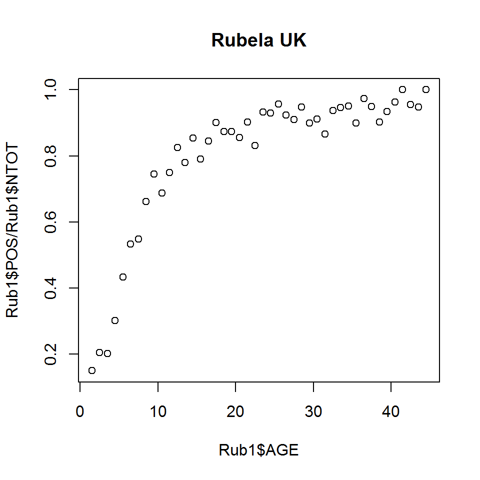

```r
plot(Rub1$AGE,Rub1$POS/Rub1$NTOT)
title("Rubela UK")
```

## 2.2 Hepatitis A in Bulgaria

```r
head(Kei1)
```

```
##   AGE POS NEG NTOT
## 1 1.5   3  13   16
## 2 2.5   3  12   15
## 3 3.5   3  13   16
## 4 4.5   4   9   13
## 5 5.5   7   5   12
## 6 6.5   4  11   15
```

```r
length(Kei1$AGE)
```

```
## [1] 83
```

```r
sum(Kei1$NTOT)
```

```
## [1] 850
```

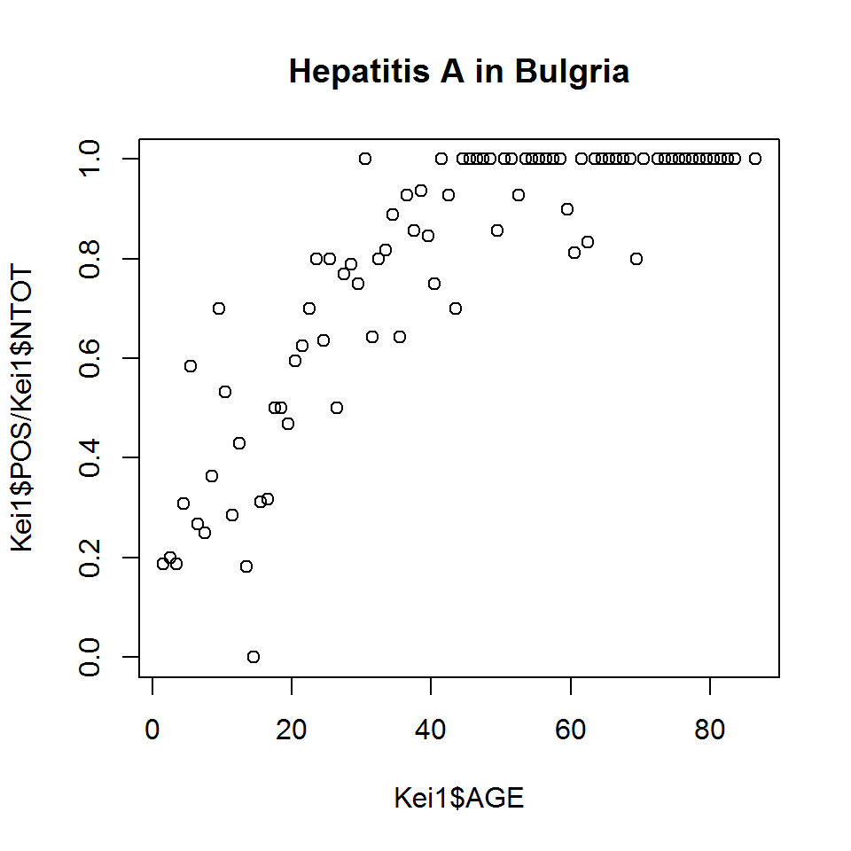

```r
plot(Kei1$AGE,Kei1$POS/Kei1$NTOT)
title("Hepatitis A in Bulgria")
```

# 3 Introduction

We assume an independent binomial distributions are assumed for the number of infected individuals ($y_{i}$) at age $a_{i}$
$$y_{i} \sim \mbox{Bin}(n_{i}, \pi_{i}),\;\;\mbox{for}\;\;i=1,2,\dots,n.$$
Here, $\pi_{i}$ is the prevalnce at age $a_{i}$ and it is assumed to be age dependent.

# 4 The exponentinal model

We assume that the prevalence is give by

$$\pi(a)=1-e^{-\lambda a},$$

with constant force of infection given by

$$\lambda(a)=\lambda.$$

## 4.1 Exponentinal model for the Hepatitis A data

In R the the exponenetial model can be fitted using the function (for the number of sero-negative) in the follwing way:

```r
fit.exp<-glm(NEG/NTOT ~ -1+AGE, family = binomial(link=log), data = Kei1)
```

Note that the linear predictor in this case is given by $-\lambda \times a$ which implies a model without intercept. Parameter estimates are shown below.

```r
summary(fit.exp)
```

```
##
## Call:
## glm(formula = NEG/NTOT ~ -1 + AGE, family = binomial(link = log),
##     data = Kei1)
##
## Deviance Residuals:
##     Min       1Q   Median       3Q      Max
## -0.7109  -0.2645  -0.1716   0.1119   1.2263
##
## Coefficients:
##      Estimate Std. Error z value Pr(>|z|)
## AGE -0.051856   0.008321  -6.232  4.6e-10 ***
## ---
## Signif. codes:  0 '***' 0.001 '**' 0.01 '*' 0.05 '.' 0.1 ' ' 1
##
## (Dispersion parameter for binomial family taken to be 1)
##
##     Null deviance:    Inf  on 83  degrees of freedom
## Residual deviance: 10.104  on 82  degrees of freedom
## AIC: 39.321
##
## Number of Fisher Scoring iterations: 6
```

The force of infection is given by

```r
lambda.exp<-fit.exp$coeff
-lambda.exp
```

```
##        AGE
## 0.05185577
```

Estimated models for both prevalence and the force of infection are sown in the follwoing figure.

```r
par(mfrow=c(1,2))
plot(Kei1$AGE,1-Kei1$NEG/Kei1$NTOT,xlab="AGE",ylab="Prevalence")
lines(Kei1$AGE,1-fit.exp$fit)
fit.exp$coeff
```

```
##         AGE
## -0.05185577
```

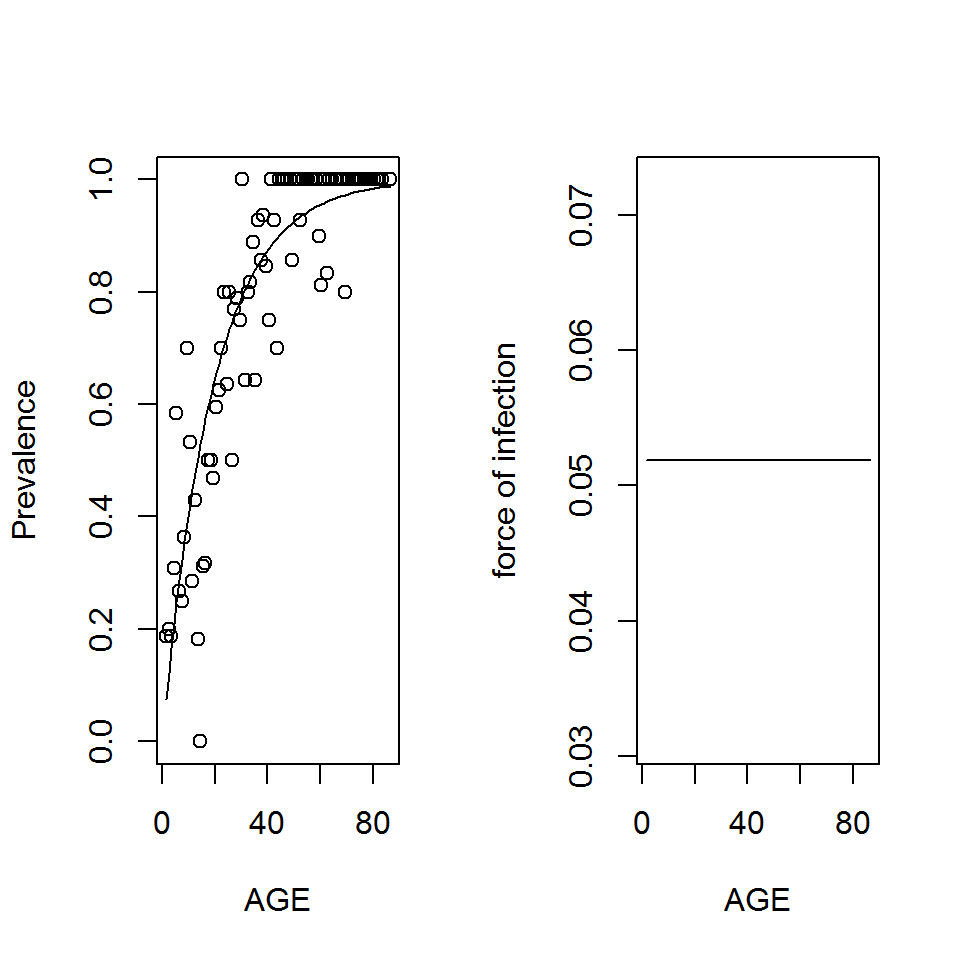

```r
plot(Kei1$AGE,rep(-fit.exp$coeff,length(Kei1$AGE)),type="l",xlab="AGE",ylab="force of infection")
```

The exponenetial model for the Rubela data can be fitted in a similar way:

```r
fit.exp<-glm(NEG/NTOT ~ -1+AGE, family = binomial(link=log), data = Rub1)
summary(fit.exp)
```

```
##
## Call:
## glm(formula = NEG/NTOT ~ -1 + AGE, family = binomial(link = log),
##     data = Rub1)
##
## Deviance Residuals:
##      Min        1Q    Median        3Q       Max
## -0.30186  -0.12183  -0.03917   0.11618   0.36208
##
## Coefficients:
##     Estimate Std. Error z value Pr(>|z|)
## AGE -0.09668    0.02117  -4.566 4.97e-06 ***
## ---
## Signif. codes:  0 '***' 0.001 '**' 0.01 '*' 0.05 '.' 0.1 ' ' 1
##
## (Dispersion parameter for binomial family taken to be 1)
##
##     Null deviance:    Inf  on 44  degrees of freedom
## Residual deviance: 1.2493  on 43  degrees of freedom
## AIC: 18.914
##
## Number of Fisher Scoring iterations: 6
```

Data, prevalence and force of infection are shown in the figure below.

```r
lambda.exp<-fit.exp$coeff
par(mfrow=c(1,2))
plot(Rub1$AGE,1-Rub1$NEG/Rub1$NTOT,xlab="AGE",ylab="Prevalence")
lines(Rub1$AGE,1-fit.exp$fit)
fit.exp$coeff
```

```
##         AGE
## -0.09668382
```

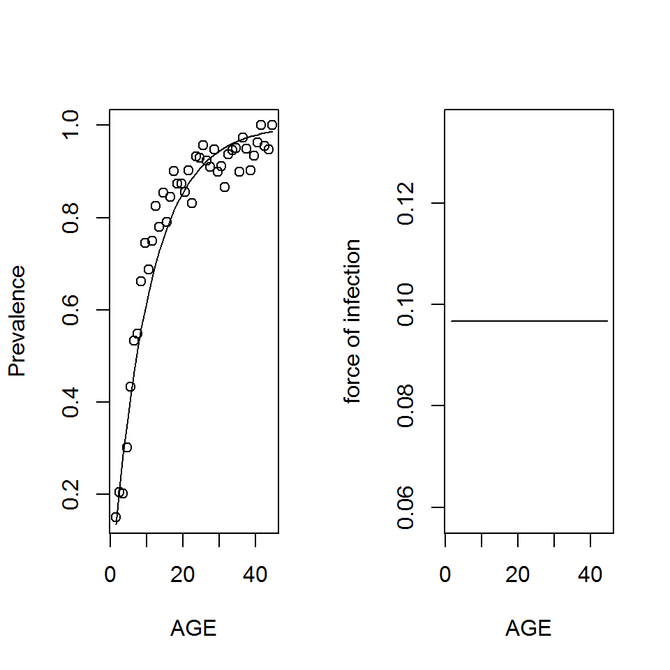

```r
plot(Rub1$AGE,rep(-fit.exp$coeff,length(Rub1$AGE)),type="l",xlab="AGE",ylab="force of infection")
```

Ziv Shkedy  
Hasselt University, Belgium

May, 10, 2020